# Descriptive statistics

Maren Westermann

#### Note: the data frame ‘adult’ was provided by DataCamp

#### Load the knitr package

```r
library(knitr)
```

## Exploring data

#### Explore the dataset with summary and str

summary(adult)  
str(adult)

#### Age histogram

ggplot(adult, aes(x = SRAGE_P)) +  
geom_histogram()

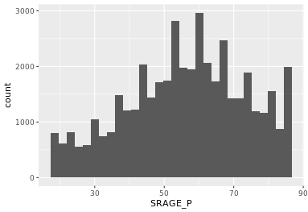

```r
include_graphics("images/exploring_data_1.png")
```

#### BMI histogram

ggplot(adult, aes(x = BMI_P)) +  
geom_histogram()

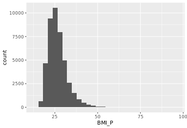

```r
include_graphics("images/exploring_data_2.png")
```

ggplot(adult, aes(x = SRAGE_P, fill = factor(RBMI))) +  
geom_histogram(binwidth = 1)

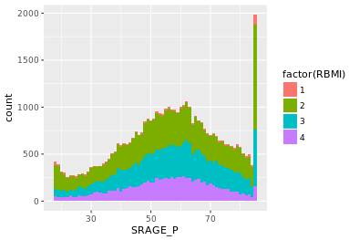

```r
include_graphics("images/exploring_data_3.png")
```

## Data cleaning

#### Remove individuals above 84

`adult <- adult[adult$SRAGE_P <= 84, ]`

#### Remove individuals with a BMI below 16 and above or equal to 52

`adult <- adult[adult$BMI_P >= 16 & adult$BMI_P < 52, ]`

#### Relabel the race variable:

`adult$RACEHPR2 <- factor(adult$RACEHPR2, labels = c("Latino", "Asian", "African American", "White"))`

## Multiple histograms

#### The color scale used in the plot

BMI_fill <- scale_fill_brewer(“BMI Category”, palette = “Reds”)

#### Theme to fix category display in faceted plot

fix_strips <- theme(strip.text.y = element_text(angle = 0, hjust = 0, vjust = 0.1, size = 14),  
strip.background = element_blank(),  
legend.position = “none”)

#### Histogram, add BMI_fill and customizations

ggplot(adult, aes (x = SRAGE_P, fill= factor(RBMI))) +  
geom_histogram(binwidth = 1) +  
fix_strips +  
BMI_fill +  
facet_grid(. ~ RBMI) +  
theme_classic()

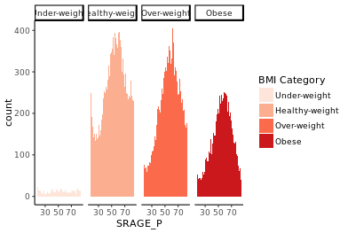

```r
include_graphics("images/multiple_histograms_1.png")
```

## Alternatives

#### Plot 1 - Count histogram

ggplot(adult, aes (x = SRAGE_P, fill= factor(RBMI))) +  
geom_histogram(binwidth = 1) +  
BMI_fill

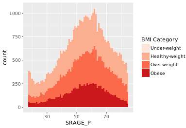

```r
include_graphics("images/alternatives_1.png")
```

#### Plot 2 - Density histogram

ggplot(adult, aes (x = SRAGE_P, fill= factor(RBMI))) +  
geom_histogram(aes(y = ..density..), binwidth = 1) +  
BMI_fill

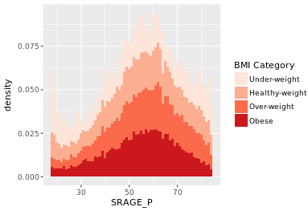

```r
include_graphics("images/alternatives_2.png")
```

#### Plot 3 - Faceted count histogram

ggplot(adult, aes (x = SRAGE_P, fill= factor(RBMI))) +  
geom_histogram(binwidth = 1) +  
BMI_fill +  
facet_grid(RBMI ~ .)

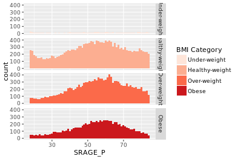

```r
include_graphics("images/alternatives_3.png")
```

#### Plot 4 - Faceted density histogram

ggplot(adult, aes (x = SRAGE_P, fill= factor(RBMI))) +  
geom_histogram(aes(y = ..density..), binwidth = 1) +  
BMI_fill +  
facet_grid(RBMI ~ .)

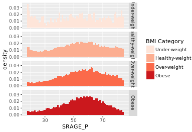

```r
include_graphics("images/alternatives_4.png")
```

#### Plot 5 - Density histogram with position = “fill”

ggplot(adult, aes (x = SRAGE_P, fill= factor(RBMI))) +  
geom_histogram(aes(y = ..density..), binwidth = 1, position = “fill”) +  
BMI_fill

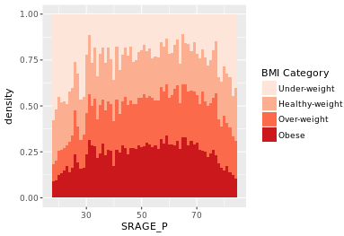

```r
include_graphics("images/alternatives_5.png")
```

#### Plot 6 - The accurate histogram

ggplot(adult, aes (x = SRAGE_P, fill= factor(RBMI))) +  
geom_histogram(aes(y = ..count../sum(..count..)), binwidth = 1, position = “fill”) +  
BMI_fill

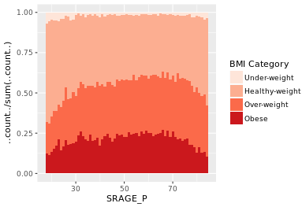

```r
include_graphics("images/alternatives_6.png")
```

## Do things manually

#### An attempt to facet the accurate frequency histogram from before (failed)

ggplot(adult, aes (x = SRAGE_P, fill= factor(RBMI))) +  
geom_histogram(aes(y = ..count../sum(..count..)), binwidth = 1, position = “fill”) +  
BMI_fill +  
facet_grid(RBMI ~ .)

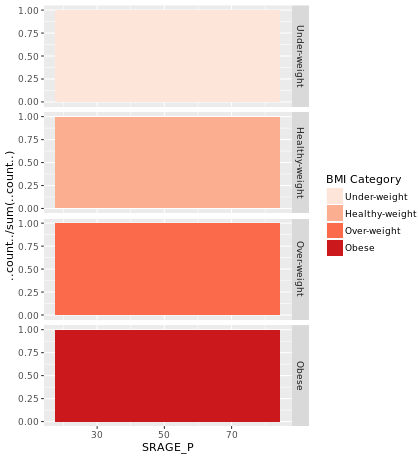

```r
include_graphics("images/do_things_manually_1.png")
```

#### Create DF with table()

`DF <- table(adult$RBMI, adult$SRAGE_P)`

#### Use apply on DF to get frequency of each group

`DF_freq <- apply(DF, 2, function(x) x/sum(x))`

#### Load reshape2 and use melt on DF to create DF_melted

`library(reshape2)` `DF_melted <- melt(DF_freq)`

#### Change names of DF_melted

`names(DF_melted) <- c("FILL", "X", "value")`

#### Add code to make this a faceted plot

ggplot(DF_melted, aes(x = X, y = value, fill = FILL)) +  
geom_bar(stat = “identity”, position = “stack”) +  
BMI_fill +  
facet_grid(FILL ~ .)

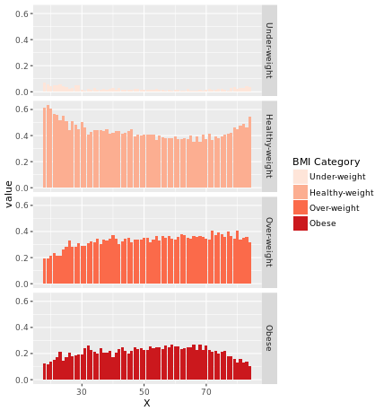

```r
include_graphics("images/do_things_manually_2.png")
```